# Clonal Expansion & Dominance Analysis

TCR Repertoire Analysis — Notebook 03

Joshua Luthy

2026-03-15

## Analysis Overview

This notebook examines **clonal expansion patterns** in the manufactured Product, identifying the most dominant clonotypes and characterizing the degree of oligoclonality. We assess whether specific clones dominate the Product and how the top clone fraction varies with clinical response.

```r
tcr_data <- read_csv("../data/raw/synthetic_tcr_repertoires.csv")
top_clones <- read_csv("../data/processed/top_clonotypes.csv")
patient_meta <- read_csv("../data/raw/patient_metadata.csv")
```

## Top Expanded Clonotypes

Below are the **top 10 expanded clonotypes** in the Product for patient PT-001 (CR). Note the extreme dominance of the top clone.

```r
top_clones %>%
  filter(patient_id == "PT-001", sample_type == "Product") %>%
  head(10) %>%
  mutate(clone_fraction_pct = paste0(round(clone_fraction * 100, 2), "%")) %>%
  select(rank, cdr3_aa, v_gene, j_gene, clone_count, clone_fraction_pct) %>%
  knitr::kable(
    caption = "Top 10 expanded clonotypes — PT-001 (CR)",
    format.args = list(big.mark = ",")
  )
```

Top 10 expanded clonotypes — PT-001 (CR)

| rank | cdr3_aa | v_gene | j_gene | clone_count | clone_fraction_pct |
| --- | --- | --- | --- | --- | --- |
| 1 | CDWVSYQFTKRRF | TRBV7-9 | TRBJ1-1 | 30,790 | 42.46% |
| 2 | CMGDVHRMPPGLMF | TRBV29-1 | TRBJ2-1 | 5,447 | 7.51% |
| 3 | CYSAQCWFMKLMYEF | TRBV29-1 | TRBJ2-1 | 1,988 | 2.74% |
| 4 | CLICPRQLPLMVNKLF | TRBV10-3 | TRBJ1-2 | 980 | 1.35% |
| 5 | CETHNLRSMQAPQSIQVF | TRBV12-4 | TRBJ1-6 | 565 | 0.78% |
| 6 | CVIYIPQNADGMSHIGF | TRBV6-5 | TRBJ2-5 | 368 | 0.51% |
| 7 | CINEITGPPDMNGIVF | TRBV18 | TRBJ1-5 | 239 | 0.33% |
| 8 | CWMWNDKGQWESRWEWIF | TRBV15 | TRBJ2-4 | 185 | 0.26% |
| 9 | CEWFQHPQDVWDRIAF | TRBV30 | TRBJ2-3 | 128 | 0.18% |
| 10 | CLGIVHPSSGGAHPVVF | TRBV27 | TRBJ1-1 | 107 | 0.15% |

## Clonal Dominance Patterns

We quantify clonal dominance by examining the **fraction of total reads** held by the top N clonotypes in each Product sample.

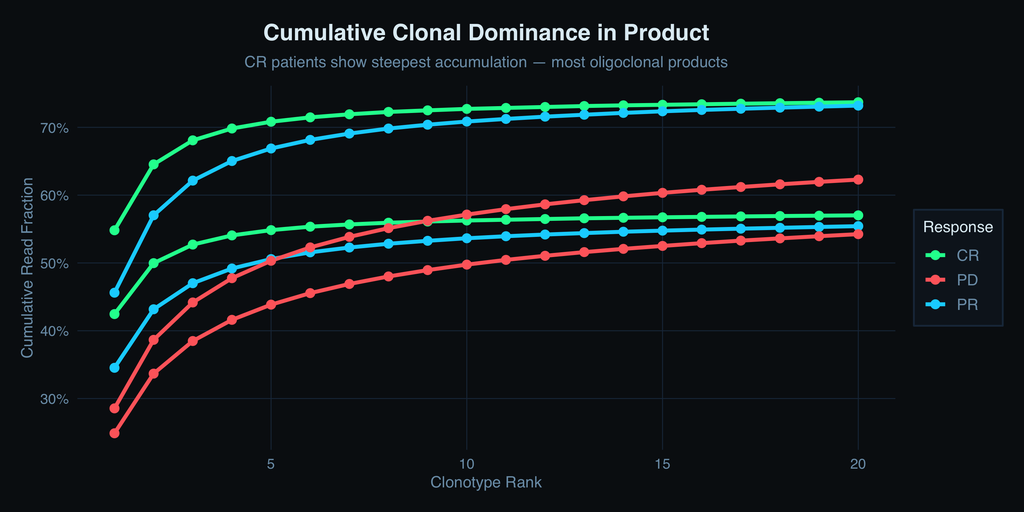

```r
cumulative <- top_clones %>%
  filter(sample_type == "Product") %>%
  group_by(patient_id, clinical_response) %>%
  arrange(rank) %>%
  mutate(cum_fraction = cumsum(clone_fraction)) %>%
  ungroup()

ggplot(cumulative, aes(x = rank, y = cum_fraction,
                        color = clinical_response, group = patient_id)) +
  geom_line(linewidth = 1.3) +
  geom_point(size = 2.5) +
  scale_color_manual(values = c("CR" = "#00ff9d", "PR" = "#00d4ff", "PD" = "#ff6b6b")) +
  scale_y_continuous(labels = scales::percent_format()) +
  labs(x = "Clonotype Rank", y = "Cumulative Read Fraction",
       color = "Response",
       title = "Cumulative Clonal Dominance in Product",
       subtitle = "CR patients show steepest accumulation — most oligoclonal products")
```